# Analysis

Eloise Newman

2022-08-14

**Please run the script/file “Data Tidying” to generate all the data sets required for this analysis to run. Files have been put in tidy_data folder to import if you are returning to this file**

```r
pan_pal <- read_csv("tidy_data/pan_pal.csv")
flymass_meta <- read_csv("tidy_data/flymass_meta.csv")
winners_losers <- read_csv("tidy_data/winners_losers.csv")
winners_losers_pair <- read_csv("tidy_data/winners_losers_pair.csv")

# temperature as a factor, again
temp_levels <- c("L", "M", "H")
flymass_meta$Temp <- factor(flymass_meta$Temp, levels =  temp_levels)
pan_pal$Temp <- factor(pan_pal$Temp, levels =  temp_levels)
winners_losers$Temp <- factor(winners_losers$Temp, levels =  temp_levels)
winners_losers_pair$Temp <- factor(winners_losers_pair$Temp, levels =  temp_levels)
```

# Statistical analysis methodology

*From thesis pages 9-11*

Data wrangling, statistical analysis and figure plotting was all performed in R version 4.1.2 (RCoreTeam, 2021). Extracted behavioural coding data from BORIS, dry mass and treatment data was combined for each pair and individual fly using the ‘tidyverse’ packages (Wickham et al., 2019). For all analyses, a p value of <0.05 was considered significant. Unless stated otherwise, count data was first modelled with a generalised linear model (GLM) using a Poisson distribution with a log link function. All models of proportional or count data were checked for over-dispersion using the linear formulation dispersion test from the package AER (Kleiber & Zeileis, 2008). If the data were over-dispersed, it violated the assumptions of a Poisson or Binomial distribution so a quasipoisson GLM was performed. Model outputs were analysed using the analysis of variance function from the car package (Fox & Weisberg, 2019).

To assess if there was variation in aggressive behaviours between treatments, the total count of agnostic behaviours was calculated for each fly (sum of body shoves, headbutts, leg shoves, lunges, wing threats and fencing bouts - table 1). As the behavioural count data was over-dispersed (z(312) = 6.770, p < 0.001) a quasipoisson GLM was fitted. As there was significant species difference in total aggressive counts (X2(1,312) = 10.229, p = 0.00138), the next model compared and tested if different species varied in the main type of aggressive behaviour displayed. Data was over-dispersed (z(1872) = 5.473, p < 0.001) so a quasipoisson model was performed. Two aggressive actions drove 93.4% of agnostic behaviour counts: fencing and leg shoves. Wing threats were also significant (t(1872) = 2.149, p = 0.0317) but only 3.42% of total counts. Hence analysis focused on aggression measures of total counts of agnostic behaviours (aggressive acts), counts of leg shoves, fencing bouts, wing threats and total fencing duration as these substantially contributed to total count of agnostic behaviour.

To minimise type II errors, a three-way GLM of sex, species and temperature treatment was conducted on each aggressive metric: fencing duration, counts of fencing and counts of leg shoves as shown:

*aggression metric ~ species * sex * temperature*

Due to several instances of no fencing, fencing duration was transformed into binary data of fencing presence due to zero-inflation. A binomial GLM was used to test the three-way-interaction with fencing presence. The number of fencing bouts data was over-dispersed (z(302) = 6.361, p < 0.001) so a quasipoisson GLM was applied to test for interactive effects. As the only significant factor was a main effect of temperature, a post-hoc Tukey test was used to determine how temperature affected fencing bouts with the non-interactive terms, sex and species, as fixed effects. A similar methodological process was followed for modelling three-way interaction of leg shoves, wing threats and subsequent tests of aggressive count data. Separate models were then fitted to each of the significant factor individually, and Tukey post-hoc tests conducted to explore the significant differences further.

411 flies were weighted to collect mass data. These flies were from all the trials, including ones not analysed in these results. A linear model was fitted showing interactive effect between sex and species. Residual standard error was 0.0425 with r2 0.887, with F(3,389) = 1022, p <0.001. A quasipoisson GLM (z(290) = 6.532, p < 0.001) was used to test if mass and total acts of aggression were correlated.

# Ways of calculating aggression

#### Aggression

Three ways of calculating aggression:

1. Total number of aggressive acts (calculated below as `total_ag_acts`)
2. Fencing Duration (`DurTTFencing`)
3. Leg shoves count (`DurNLegShove`)

*“count data was first modelled with a generalised linear model (GLM) using a Poisson distribution with a log link function. All models of proportional or count data were checked for over-dispersion using the linear formulation dispersion test from the package AER (Kleiber & Zeileis, 2008). If the data were over-dispersed, it violated the assumptions of a Poisson or Binomial distribution so a quasipoisson GLM was performed.Model outputs were analysed using the analysis of variance function from the car package (Fox & Weisberg, 2019).”*

# Is there variation in aggression between treatments?

the **total count of agnostic behaviours** was calculated for each fly (sum of body shoves, headbutts, leg shoves, lunges, wing threats and fencing bouts - table 1).

```r
glm_species_taa <- glm(total_ag_acts ~ Species, pan_pal,
                       family = poisson())
summary(glm_species_taa)
```

```
##
## Call:
## glm(formula = total_ag_acts ~ Species, family = poisson(), data = pan_pal)
##
## Deviance Residuals:
##     Min       1Q   Median       3Q      Max
## -4.0991  -2.3919  -1.1984   0.9614   9.5718
##
## Coefficients:
##             Estimate Std. Error z value Pr(>|z|)
## (Intercept)  2.12838    0.02753   77.30   <2e-16 ***
## SpeciesPAN  -0.40926    0.04359   -9.39   <2e-16 ***
## ---
## Signif. codes:  0 '***' 0.001 '**' 0.01 '*' 0.05 '.' 0.1 ' ' 1
##
## (Dispersion parameter for poisson family taken to be 1)
##
##     Null deviance: 2468.9  on 313  degrees of freedom
## Residual deviance: 2378.9  on 312  degrees of freedom
## AIC: 3333.2
##
## Number of Fisher Scoring iterations: 5
```

```r
dispersiontest(glm_species_taa, trafo = 1) # overdispersed
```

```
##
##  Overdispersion test
##
## data:  glm_species_taa
## z = 6.7704, p-value = 6.423e-12
## alternative hypothesis: true alpha is greater than 0
## sample estimates:
##    alpha
## 7.744296
```

As the behavioural count data was **over-dispersed** (z(312) = 6.770, p < 0.001) a **quasipoisson GLM** was fitted.

```r
glm_species_taa <- glm(total_ag_acts ~ Species, pan_pal, family = quasipoisson())
summary(glm_species_taa)
```

```
##
## Call:
## glm(formula = total_ag_acts ~ Species, family = quasipoisson(),
##     data = pan_pal)
##
## Deviance Residuals:
##     Min       1Q   Median       3Q      Max
## -4.0991  -2.3919  -1.1984   0.9614   9.5718
##
## Coefficients:
##             Estimate Std. Error t value Pr(>|t|)
## (Intercept)  2.12838    0.08168  26.057   <2e-16 ***
## SpeciesPAN  -0.40926    0.12930  -3.165   0.0017 **
## ---
## Signif. codes:  0 '***' 0.001 '**' 0.01 '*' 0.05 '.' 0.1 ' ' 1
##
## (Dispersion parameter for quasipoisson family taken to be 8.800526)
##
##     Null deviance: 2468.9  on 313  degrees of freedom
## Residual deviance: 2378.9  on 312  degrees of freedom
## AIC: NA
##
## Number of Fisher Scoring iterations: 5
```

```r
Anova(glm_species_taa)
```

```
## Analysis of Deviance Table (Type II tests)
##
## Response: total_ag_acts
##         LR Chisq Df Pr(>Chisq)
## Species   10.229  1   0.001382 **
## ---
## Signif. codes:  0 '***' 0.001 '**' 0.01 '*' 0.05 '.' 0.1 ' ' 1
```

Using a quasipoisson as overdispersed, yes species are significantly different in total aggressive counts (X2 = 10.229, p = 0.001383 **). On average PAL (2.1283, t=26.057 p = <0.001) is more aggressive than PAN (est = 1.71912, t-value = -3.165, p = 0.0017).

PAN and PAL have significantly different total count of aggressive behaviours (X2(1,312) = 10.229, p = 0.001382). PAL exhibits a greater total average count of aggressive behaviours (estimate = 2.1283, se = 0.08168) than PAN (estimate = 1.71912, se = 0.12930).

# Do different species vary in the type of aggressive behaviours displayed?

As there was significant species difference in total aggressive counts (X2(1,312) = 10.229, p = 0.00138), the next model compared and tested **if different species varied in the main type of aggressive behaviour** displayed.

```r
glm_species_taa_int <- glm(total_ag_acts ~ Species * Sex * Temp, pan_pal,
                       family = poisson())
summary(glm_species_taa_int)
```

```
##
## Call:
## glm(formula = total_ag_acts ~ Species * Sex * Temp, family = poisson(),
##     data = pan_pal)
##
## Deviance Residuals:
##     Min       1Q   Median       3Q      Max
## -5.0990  -2.2690  -0.8420   0.8028  10.2654
##
## Coefficients:
##                       Estimate Std. Error z value Pr(>|z|)
## (Intercept)            2.56495    0.05547  46.240  < 2e-16 ***
## SpeciesPAN            -0.43672    0.08854  -4.933 8.11e-07 ***
## SexM                  -0.25044    0.08384  -2.987  0.00282 **
## TempM                 -0.45676    0.08441  -5.411 6.26e-08 ***
## TempH                 -0.77319    0.09740  -7.938 2.05e-15 ***
## SpeciesPAN:SexM        0.16082    0.13038   1.233  0.21740
## SpeciesPAN:TempM      -0.02281    0.13527  -0.169  0.86606
## SpeciesPAN:TempH      -0.13580    0.16004  -0.849  0.39613
## SexM:TempM             0.10390    0.12761   0.814  0.41553
## SexM:TempH             0.26423    0.14243   1.855  0.06358 .
## SpeciesPAN:SexM:TempM -0.11460    0.20134  -0.569  0.56924
## SpeciesPAN:SexM:TempH  0.06282    0.22656   0.277  0.78157
## ---
## Signif. codes:  0 '***' 0.001 '**' 0.01 '*' 0.05 '.' 0.1 ' ' 1
##
## (Dispersion parameter for poisson family taken to be 1)
##
##     Null deviance: 2468.9  on 313  degrees of freedom
## Residual deviance: 2187.1  on 302  degrees of freedom
## AIC: 3161.4
##
## Number of Fisher Scoring iterations: 5
```

```r
dispersiontest(glm_species_taa_int, trafo = 1) # overdispersed
```

```
##
##  Overdispersion test
##
## data:  glm_species_taa_int
## z = 5.4159, p-value = 3.049e-08
## alternative hypothesis: true alpha is greater than 0
## sample estimates:
##    alpha
## 7.477006
```

```r
glm_species_taa_int <- glm(total_ag_acts ~ Species * Sex * Temp, pan_pal, family = quasipoisson())
summary(glm_species_taa_int)
```

```
##
## Call:
## glm(formula = total_ag_acts ~ Species * Sex * Temp, family = quasipoisson(),
##     data = pan_pal)
##
## Deviance Residuals:
##     Min       1Q   Median       3Q      Max
## -5.0990  -2.2690  -0.8420   0.8028  10.2654
##
## Coefficients:
##                       Estimate Std. Error t value Pr(>|t|)
## (Intercept)            2.56495    0.16469  15.575  < 2e-16 ***
## SpeciesPAN            -0.43672    0.26286  -1.661  0.09767 .
## SexM                  -0.25044    0.24892  -1.006  0.31518
## TempM                 -0.45676    0.25061  -1.823  0.06935 .
## TempH                 -0.77319    0.28918  -2.674  0.00791 **
## SpeciesPAN:SexM        0.16082    0.38710   0.415  0.67810
## SpeciesPAN:TempM      -0.02281    0.40160  -0.057  0.95473
## SpeciesPAN:TempH      -0.13580    0.47515  -0.286  0.77522
## SexM:TempM             0.10390    0.37888   0.274  0.78409
## SexM:TempH             0.26423    0.42287   0.625  0.53255
## SpeciesPAN:SexM:TempM -0.11460    0.59778  -0.192  0.84810
## SpeciesPAN:SexM:TempH  0.06282    0.67264   0.093  0.92566
## ---
## Signif. codes:  0 '***' 0.001 '**' 0.01 '*' 0.05 '.' 0.1 ' ' 1
##
## (Dispersion parameter for quasipoisson family taken to be 8.814626)
##
##     Null deviance: 2468.9  on 313  degrees of freedom
## Residual deviance: 2187.1  on 302  degrees of freedom
## AIC: NA
##
## Number of Fisher Scoring iterations: 5
```

```r
Anova(glm_species_taa_int, type = 3)
```

```
## Analysis of Deviance Table (Type III tests)
##
## Response: total_ag_acts
##                  LR Chisq Df Pr(>Chisq)
## Species            2.8264  1    0.09273 .
## Sex                1.0201  1    0.31248
## Temp               8.0017  2    0.01830 *
## Species:Sex        0.1726  1    0.67780
## Species:Temp       0.0847  2    0.95852
## Sex:Temp           0.3914  2    0.82225
## Species:Sex:Temp   0.0683  2    0.96641
## ---
## Signif. codes:  0 '***' 0.001 '**' 0.01 '*' 0.05 '.' 0.1 ' ' 1
```

## What is the most frequent agonistic behaviour?

As total aggressive acts are significantly different between species, break it down to see what kind of agnostic behaviours vary between the species. Is there any evidence that flies express some behaviours more frequently than others? Does it vary between species?

```r
pan_pal_ag <- pan_pal %>%
  pivot_longer(c(2, 4:7, 10), names_to = "ag_act", values_to = "Count") %>%
 dplyr::select(Fly_Number, file_name, Letter, Sex, Temp, Species,
        DurTTMoving, DurTTFeed, DurTTFencing,
         Mass, mass_dif, total_ag_acts, ag_act, Count)

glm_species_ag_acts <- glm(Count ~ Species * ag_act, pan_pal_ag,
                           family = poisson())
summary(glm_species_ag_acts)
```

```
##
## Call:
## glm(formula = Count ~ Species * ag_act, family = poisson(), data = pan_pal_ag)
##
## Deviance Residuals:
##     Min       1Q   Median       3Q      Max
## -2.9324  -0.6865  -0.3569  -0.1596   7.9387
##
## Coefficients:
##                                 Estimate Std. Error z value Pr(>|z|)
## (Intercept)                      -2.7537     0.3162  -8.708  < 2e-16 ***
## SpeciesPAN                       -1.6094     0.7745  -2.078 0.037717 *
## ag_actDurNFencing                 4.2121     0.3186  13.222  < 2e-16 ***
## ag_actDurNHeadbutt               -1.2040     0.6583  -1.829 0.067402 .
## ag_actDurNLegShove                4.0395     0.3190  12.663  < 2e-16 ***
## ag_actDurNLunge                   0.9555     0.3721   2.568 0.010233 *
## ag_actDurNWingThreat              1.3083     0.3564   3.671 0.000242 ***
## SpeciesPAN:ag_actDurNFencing      1.6080     0.7765   2.071 0.038369 *
## SpeciesPAN:ag_actDurNHeadbutt     1.8971     1.0878   1.744 0.081151 .
## SpeciesPAN:ag_actDurNLegShove     0.1349     0.7806   0.173 0.862849
## SpeciesPAN:ag_actDurNLunge        1.6835     0.8210   2.051 0.040313 *
## SpeciesPAN:ag_actDurNWingThreat   1.6361     0.8082   2.024 0.042942 *
## ---
## Signif. codes:  0 '***' 0.001 '**' 0.01 '*' 0.05 '.' 0.1 ' ' 1
##
## (Dispersion parameter for poisson family taken to be 1)
##
##     Null deviance: 7421.5  on 1883  degrees of freedom
## Residual deviance: 3278.1  on 1872  degrees of freedom
## AIC: 4836.9
##
## Number of Fisher Scoring iterations: 6
```

```r
dispersiontest(glm_species_ag_acts, trafo = 1)
```

```
##
##  Overdispersion test
##
## data:  glm_species_ag_acts
## z = 5.4729, p-value = 2.213e-08
## alternative hypothesis: true alpha is greater than 0
## sample estimates:
##    alpha
## 1.898507
```

But overdispersed

```r
glm_species_ag_acts_qp <- glm(Count ~ Species * ag_act, pan_pal_ag, family = quasipoisson())

summary(glm_species_ag_acts_qp)
```

```
##
## Call:
## glm(formula = Count ~ Species * ag_act, family = quasipoisson(),
##     data = pan_pal_ag)
##
## Deviance Residuals:
##     Min       1Q   Median       3Q      Max
## -2.9324  -0.6865  -0.3569  -0.1596   7.9387
##
## Coefficients:
##                                 Estimate Std. Error t value Pr(>|t|)
## (Intercept)                      -2.7537     0.5401  -5.098 3.77e-07 ***
## SpeciesPAN                       -1.6094     1.3229  -1.217   0.2239
## ag_actDurNFencing                 4.2121     0.5441   7.742 1.60e-14 ***
## ag_actDurNHeadbutt               -1.2040     1.1243  -1.071   0.2844
## ag_actDurNLegShove                4.0395     0.5448   7.414 1.84e-13 ***
## ag_actDurNLunge                   0.9555     0.6355   1.503   0.1329
## ag_actDurNWingThreat              1.3083     0.6087   2.149   0.0317 *
## SpeciesPAN:ag_actDurNFencing      1.6080     1.3262   1.212   0.2255
## SpeciesPAN:ag_actDurNHeadbutt     1.8971     1.8579   1.021   0.3073
## SpeciesPAN:ag_actDurNLegShove     0.1349     1.3333   0.101   0.9194
## SpeciesPAN:ag_actDurNLunge        1.6835     1.4023   1.201   0.2301
## SpeciesPAN:ag_actDurNWingThreat   1.6361     1.3805   1.185   0.2361
## ---
## Signif. codes:  0 '***' 0.001 '**' 0.01 '*' 0.05 '.' 0.1 ' ' 1
##
## (Dispersion parameter for quasipoisson family taken to be 2.917178)
##
##     Null deviance: 7421.5  on 1883  degrees of freedom
## Residual deviance: 3278.1  on 1872  degrees of freedom
## AIC: NA
##
## Number of Fisher Scoring iterations: 6
```

```r
Anova(glm_species_ag_acts_qp, type = 3)
```

```
## Analysis of Deviance Table (Type III tests)
##
## Response: Count
##                LR Chisq Df Pr(>Chisq)
## Species            2.00  1     0.1577
## ag_act           775.54  5  < 2.2e-16 ***
## Species:ag_act    72.86  5  2.595e-14 ***
## ---
## Signif. codes:  0 '***' 0.001 '**' 0.01 '*' 0.05 '.' 0.1 ' ' 1
```

Two aggressive actions drove 93.4% of agnostic behaviour counts: fencing and leg shoves. Wing threats were also significant (t(1872) = 2.149, p = 0.0317) but only 3.42% of total counts. Hence analysis focused on aggression measures of total counts of agnostic behaviours (aggressive acts), counts of leg shoves, fencing bouts, wing threats and total fencing duration as these substantially contributed to total count of agnostic behaviour.

# Does temperature or sex affect the types of aggressive behaviour displayed?

To minimise type II errors, a three-way GLM of sex, species and temperature treatment was conducted on each aggressive metric: fencing duration, counts of fencing and counts of leg shoves as shown:

*aggression metric ~ species * sex * temperature*

1. check linear,
2. dispersion test,
3. then quasipossion glm,
4. post-hoc tukey test to determine how x affected y with non-interactive terms as fixed effects

A similar methodological process was followed for modelling three-way interaction of leg shoves, wing threats and subsequent tests of aggressive count data. Separate models were then fitted to each of the significant factor individually, and Tukey post-hoc tests conducted to explore the significant differences further.

## Three way interactions: Sex * Species * Temp

### Fencing duration

Due to several instances of no fencing, fencing duration was transformed into binary data of fencing presence due to zero-inflation. A binomial GLM was used to test the three-way-interaction with fencing presence.

```r
glm_three_fp <- glm(fencing_presence ~ Species * Sex * Temp, pan_pal, family = binomial())
summary(glm_three_fp)
```

```
##
## Call:
## glm(formula = fencing_presence ~ Species * Sex * Temp, family = binomial(),
##     data = pan_pal)
##
## Deviance Residuals:
##     Min       1Q   Median       3Q      Max
## -2.0963   0.4854   0.5056   0.7876   0.7920
##
## Coefficients:
##                         Estimate Std. Error z value Pr(>|z|)
## (Intercept)            1.992e+00  6.155e-01   3.237  0.00121 **
## SpeciesPAN            -3.342e-01  8.224e-01  -0.406  0.68448
## SexM                  -3.790e-15  8.704e-01   0.000  1.00000
## TempM                 -9.808e-01  7.411e-01  -1.323  0.18568
## TempH                 -9.939e-01  7.578e-01  -1.312  0.18967
## SpeciesPAN:SexM        3.342e-01  1.197e+00   0.279  0.78018
## SpeciesPAN:TempM       3.342e-01  1.009e+00   0.331  0.74038
## SpeciesPAN:TempH       3.342e-01  1.033e+00   0.323  0.74633
## SexM:TempM             1.068e+00  1.141e+00   0.935  0.34954
## SexM:TempH             1.001e-01  1.084e+00   0.092  0.92644
## SpeciesPAN:SexM:TempM -3.342e-01  1.589e+00  -0.210  0.83341
## SpeciesPAN:SexM:TempH -3.342e-01  1.506e+00  -0.222  0.82443
## ---
## Signif. codes:  0 '***' 0.001 '**' 0.01 '*' 0.05 '.' 0.1 ' ' 1
##
## (Dispersion parameter for binomial family taken to be 1)
##
##     Null deviance: 309.20  on 313  degrees of freedom
## Residual deviance: 298.85  on 302  degrees of freedom
## AIC: 322.85
##
## Number of Fisher Scoring iterations: 4
```

```r
Anova(glm_three_fp, type =3)
```

```
## Analysis of Deviance Table (Type III tests)
##
## Response: fencing_presence
##                  LR Chisq Df Pr(>Chisq)
## Species           0.16660  1     0.6831
## Sex               0.00000  1     1.0000
## Temp              2.38165  2     0.3040
## Species:Sex       0.07803  1     0.7800
## Species:Temp      0.13087  2     0.9367
## Sex:Temp          1.29276  2     0.5239
## Species:Sex:Temp  0.05863  2     0.9711
```

Nothing was significantly different between sex, species and temperature in fencing presence. There were no interactive effects.

### Fencing counts

```r
glm_three_fc <- glm(DurNFencing ~ Species * Sex * Temp, pan_pal,
                    family = poisson())
summary(glm_three_fc)
```

```
##
## Call:
## glm(formula = DurNFencing ~ Species * Sex * Temp, family = poisson(),
##     data = pan_pal)
##
## Deviance Residuals:
##     Min       1Q   Median       3Q      Max
## -3.6770  -1.6265  -0.6785   0.8162   6.3641
##
## Coefficients:
##                        Estimate Std. Error z value Pr(>|z|)
## (Intercept)            1.911023   0.076923  24.843  < 2e-16 ***
## SpeciesPAN            -0.011905   0.109111  -0.109 0.913117
## SexM                  -0.217244   0.115196  -1.886 0.059313 .
## TempM                 -0.444686   0.116658  -3.812 0.000138 ***
## TempH                 -0.892453   0.140733  -6.341 2.28e-10 ***
## SpeciesPAN:SexM        0.033724   0.162642   0.207 0.835736
## SpeciesPAN:TempM       0.004183   0.165374   0.025 0.979821
## SpeciesPAN:TempH       0.025698   0.198727   0.129 0.897109
## SexM:TempM            -0.023142   0.178413  -0.130 0.896798
## SexM:TempH             0.351354   0.200789   1.750 0.080141 .
## SpeciesPAN:SexM:TempM -0.036931   0.252495  -0.146 0.883713
## SpeciesPAN:SexM:TempH -0.060762   0.283777  -0.214 0.830453
## ---
## Signif. codes:  0 '***' 0.001 '**' 0.01 '*' 0.05 '.' 0.1 ' ' 1
##
## (Dispersion parameter for poisson family taken to be 1)
##
##     Null deviance: 1440.9  on 313  degrees of freedom
## Residual deviance: 1308.2  on 302  degrees of freedom
## AIC: 2147.2
##
## Number of Fisher Scoring iterations: 5
```

```r
dispersiontest(glm_three_fc, trafo = 1)
```

```
##
##  Overdispersion test
##
## data:  glm_three_fc
## z = 6.3607, p-value = 1.004e-10
## alternative hypothesis: true alpha is greater than 0
## sample estimates:
##    alpha
## 3.526329
```

The number of fencing bouts data was over-dispersed (z(302) = 6.361, p < 0.001) so a quasipoisson GLM was applied to test for interactive effects.

```r
glm_three_fc <- glm(DurNFencing ~ Species * Sex * Temp, pan_pal,
                    family = quasipoisson())
summary(glm_three_fc)
```

```
##
## Call:
## glm(formula = DurNFencing ~ Species * Sex * Temp, family = quasipoisson(),
##     data = pan_pal)
##
## Deviance Residuals:
##     Min       1Q   Median       3Q      Max
## -3.6770  -1.6265  -0.6785   0.8162   6.3641
##
## Coefficients:
##                        Estimate Std. Error t value Pr(>|t|)
## (Intercept)            1.911023   0.166877  11.452  < 2e-16 ***
## SpeciesPAN            -0.011905   0.236705  -0.050  0.95992
## SexM                  -0.217244   0.249906  -0.869  0.38537
## TempM                 -0.444686   0.253078  -1.757  0.07991 .
## TempH                 -0.892453   0.305307  -2.923  0.00373 **
## SpeciesPAN:SexM        0.033724   0.352836   0.096  0.92392
## SpeciesPAN:TempM       0.004183   0.358763   0.012  0.99071
## SpeciesPAN:TempH       0.025698   0.431119   0.060  0.95251
## SexM:TempM            -0.023142   0.387051  -0.060  0.95236
## SexM:TempH             0.351354   0.435591   0.807  0.42052
## SpeciesPAN:SexM:TempM -0.036931   0.547765  -0.067  0.94629
## SpeciesPAN:SexM:TempH -0.060762   0.615627  -0.099  0.92144
## ---
## Signif. codes:  0 '***' 0.001 '**' 0.01 '*' 0.05 '.' 0.1 ' ' 1
##
## (Dispersion parameter for quasipoisson family taken to be 4.706313)
##
##     Null deviance: 1440.9  on 313  degrees of freedom
## Residual deviance: 1308.2  on 302  degrees of freedom
## AIC: NA
##
## Number of Fisher Scoring iterations: 5
```

```r
Anova(glm_three_fc, type = 3)
```

```
## Analysis of Deviance Table (Type III tests)
##
## Response: DurNFencing
##                  LR Chisq Df Pr(>Chisq)
## Species            0.0025  1   0.959888
## Sex                0.7601  1   0.383282
## Temp               9.4993  2   0.008655 **
## Species:Sex        0.0091  1   0.923853
## Species:Temp       0.0037  2   0.998168
## Sex:Temp           0.7999  2   0.670369
## Species:Sex:Temp   0.0109  2   0.994588
## ---
## Signif. codes:  0 '***' 0.001 '**' 0.01 '*' 0.05 '.' 0.1 ' ' 1
```

Looking at the model, High temperature was significantly different from low temperature (est=1.911023-0.892453, t-value = -2.923, p = 0.00373) with a lower number of bouts. Medium temperature did not significantly differ from either high or low temperatures.

As the only significant factor was a main effect of temperature, a post-hoc Tukey test was used to determine how temperature affected fencing bouts with the non-interactive terms, sex and species, as fixed effects.

```r
glm_three_fc_ph <- glm(DurNFencing ~ Temp + Sex + Species, pan_pal, family = quasipoisson()) # no interaction thus add
summary(glht(glm_three_fc_ph, mcp(Temp = "Tukey"))) #multcomp package
```

```
##
##   Simultaneous Tests for General Linear Hypotheses
##
## Multiple Comparisons of Means: Tukey Contrasts
##
##
## Fit: glm(formula = DurNFencing ~ Temp + Sex + Species, family = quasipoisson(),
##     data = pan_pal)
##
## Linear Hypotheses:
##            Estimate Std. Error z value Pr(>|z|)
## M - L == 0  -0.4586     0.1352  -3.392  0.00205 **
## H - L == 0  -0.7276     0.1533  -4.746  < 0.001 ***
## H - M == 0  -0.2690     0.1626  -1.655  0.22155
## ---
## Signif. codes:  0 '***' 0.001 '**' 0.01 '*' 0.05 '.' 0.1 ' ' 1
## (Adjusted p values reported -- single-step method)
```

Post hoc test to see temperatures (add species and sex as no interaction), showed that M-L were significantly different (est = - 0.4586, z = -3.392, p = 0.00212) and H-L were sig different (est- -0.7276, z = -4.746, p < 0.001). But that High medium difference was not significant (z = -1.655, p = 0.22141). With low having the highest number of bouts, then medium then high temperature.

### Leg shove counts

```r
glm_three_lsc <- glm(DurNLegShove ~ Species * Sex * Temp, pan_pal, family = poisson())
summary(glm_three_lsc)
```

```
##
## Call:
## glm(formula = DurNLegShove ~ Species * Sex * Temp, family = poisson(),
##     data = pan_pal)
##
## Deviance Residuals:
##     Min       1Q   Median       3Q      Max
## -3.3106  -1.3806  -0.9052   0.4359   8.2426
##
## Coefficients:
##                        Estimate Std. Error z value Pr(>|z|)
## (Intercept)            1.701105   0.085436  19.911  < 2e-16 ***
## SpeciesPAN            -1.364633   0.189396  -7.205  5.8e-13 ***
## SexM                  -0.295008   0.130779  -2.256 0.024085 *
## TempM                 -0.429474   0.129016  -3.329 0.000872 ***
## TempH                 -0.577175   0.140710  -4.102  4.1e-05 ***
## SpeciesPAN:SexM        0.071865   0.285287   0.252 0.801117
## SpeciesPAN:TempM      -0.130142   0.294759  -0.442 0.658837
## SpeciesPAN:TempH      -0.820169   0.399350  -2.054 0.039999 *
## SexM:TempM             0.096988   0.197755   0.490 0.623821
## SexM:TempH             0.136159   0.213251   0.638 0.523154
## SpeciesPAN:SexM:TempM -0.002098   0.444621  -0.005 0.996234
## SpeciesPAN:SexM:TempH  0.677853   0.536225   1.264 0.206187
## ---
## Signif. codes:  0 '***' 0.001 '**' 0.01 '*' 0.05 '.' 0.1 ' ' 1
##
## (Dispersion parameter for poisson family taken to be 1)
##
##     Null deviance: 1394.9  on 313  degrees of freedom
## Residual deviance: 1041.3  on 302  degrees of freedom
## AIC: 1572.1
##
## Number of Fisher Scoring iterations: 6
```

```r
dispersiontest(glm_three_lsc, trafo = 1)
```

```
##
##  Overdispersion test
##
## data:  glm_three_lsc
## z = 4.1692, p-value = 1.528e-05
## alternative hypothesis: true alpha is greater than 0
## sample estimates:
##    alpha
## 3.587406
```

poission overdispersed (z = 4.1692, p = 1.528e-05)

```r
glm_three_lsc <- glm(DurNLegShove ~ Species * Sex * Temp, pan_pal,
                     family = quasipoisson())
summary(glm_three_lsc)
```

```
##
## Call:
## glm(formula = DurNLegShove ~ Species * Sex * Temp, family = quasipoisson(),
##     data = pan_pal)
##
## Deviance Residuals:
##     Min       1Q   Median       3Q      Max
## -3.3106  -1.3806  -0.9052   0.4359   8.2426
##
## Coefficients:
##                        Estimate Std. Error t value Pr(>|t|)
## (Intercept)            1.701105   0.186589   9.117  < 2e-16 ***
## SpeciesPAN            -1.364633   0.413635  -3.299  0.00109 **
## SexM                  -0.295008   0.285618  -1.033  0.30249
## TempM                 -0.429474   0.281767  -1.524  0.12850
## TempH                 -0.577175   0.307306  -1.878  0.06132 .
## SpeciesPAN:SexM        0.071865   0.623059   0.115  0.90825
## SpeciesPAN:TempM      -0.130142   0.643746  -0.202  0.83992
## SpeciesPAN:TempH      -0.820169   0.872169  -0.940  0.34777
## SexM:TempM             0.096988   0.431892   0.225  0.82247
## SexM:TempH             0.136159   0.465735   0.292  0.77022
## SpeciesPAN:SexM:TempM -0.002098   0.971040  -0.002  0.99828
## SpeciesPAN:SexM:TempH  0.677853   1.171100   0.579  0.56314
## ---
## Signif. codes:  0 '***' 0.001 '**' 0.01 '*' 0.05 '.' 0.1 ' ' 1
##
## (Dispersion parameter for quasipoisson family taken to be 4.769729)
##
##     Null deviance: 1394.9  on 313  degrees of freedom
## Residual deviance: 1041.3  on 302  degrees of freedom
## AIC: NA
##
## Number of Fisher Scoring iterations: 6
```

```r
Anova(glm_three_lsc, type = 3)
```

```
## Analysis of Deviance Table (Type III tests)
##
## Response: DurNLegShove
##                  LR Chisq Df Pr(>Chisq)
## Species           13.5550  1  0.0002317 ***
## Sex                1.0785  1  0.2990405
## Temp               4.1390  2  0.1262477
## Species:Sex        0.0133  1  0.9082482
## Species:Temp       1.0132  2  0.6025363
## Sex:Temp           0.0990  2  0.9517251
## Species:Sex:Temp   0.3887  2  0.8233789
## ---
## Signif. codes:  0 '***' 0.001 '**' 0.01 '*' 0.05 '.' 0.1 ' ' 1
```

Significant difference in species over leg shove count (chisq = 13.550, p = 0.0002317 <0.0001). PAL female low temperature mean estimate is 1.701105 +/ 0.186589 (t-value = 9.117, p <0.00001). PAN females at low temperature have signficiantly lower leg shove count. (1.701105-1.364633 = 0.336472, t-value = -3.299, p = 0.00109). No significant interaction of sex or temperature, nor significant interactive effects with species.

### Wing threats counts

```r
glm_three_wt <- glm(DurNWingThreat ~ Species * Sex * Temp, pan_pal,
                    family = poisson())
summary(glm_three_wt)
```

```
##
## Call:
## glm(formula = DurNWingThreat ~ Species * Sex * Temp, family = poisson(),
##     data = pan_pal)
##
## Deviance Residuals:
##     Min       1Q   Median       3Q      Max
## -1.1662  -0.7483  -0.5774  -0.2887   6.9135
##
## Coefficients:
##                       Estimate Std. Error z value Pr(>|z|)
## (Intercept)            -0.8210     0.3015  -2.723  0.00647 **
## SpeciesPAN             -0.7885     0.5394  -1.462  0.14379
## SexM                   -0.4520     0.4835  -0.935  0.34988
## TempM                  -0.9708     0.5394  -1.800  0.07188 .
## TempH                 -16.4816   680.1031  -0.024  0.98067
## SpeciesPAN:SexM         1.6758     0.7018   2.388  0.01696 *
## SpeciesPAN:TempM       -0.1278     0.9954  -0.128  0.89782
## SpeciesPAN:TempH       16.2192   680.1034   0.024  0.98097
## SexM:TempM              1.5129     0.7146   2.117  0.03426 *
## SexM:TempH             14.5765   680.1039   0.021  0.98290
## SpeciesPAN:SexM:TempM  -1.5327     1.1984  -1.279  0.20093
## SpeciesPAN:SexM:TempH -15.7202   680.1045  -0.023  0.98156
## ---
## Signif. codes:  0 '***' 0.001 '**' 0.01 '*' 0.05 '.' 0.1 ' ' 1
##
## (Dispersion parameter for poisson family taken to be 1)
##
##     Null deviance: 377.73  on 313  degrees of freedom
## Residual deviance: 329.50  on 302  degrees of freedom
## AIC: 442.16
##
## Number of Fisher Scoring iterations: 15
```

```r
Anova(glm_three_wt, type = 3)
```

```
## Analysis of Deviance Table (Type III tests)
##
## Response: DurNWingThreat
##                  LR Chisq Df Pr(>Chisq)
## Species            2.3059  1  0.1288798
## Sex                0.8964  1  0.3437614
## Temp              15.9204  2  0.0003491 ***
## Species:Sex        6.2018  1  0.0127624 *
## Species:Temp       8.2481  2  0.0161787 *
## Sex:Temp           5.9684  2  0.0505800 .
## Species:Sex:Temp   4.0720  2  0.1305525
## ---
## Signif. codes:  0 '***' 0.001 '**' 0.01 '*' 0.05 '.' 0.1 ' ' 1
```

```r
dispersiontest(glm_three_wt, trafo = 1)
```

```
##
##  Overdispersion test
##
## data:  glm_three_wt
## z = 2.084, p-value = 0.01858
## alternative hypothesis: true alpha is greater than 0
## sample estimates:
##    alpha
## 1.721666
```

```r
glm_three_wt <- glm(DurNWingThreat ~ Species * Sex * Temp, pan_pal,
                    family = quasipoisson())
summary(glm_three_wt)
```

```
##
## Call:
## glm(formula = DurNWingThreat ~ Species * Sex * Temp, family = quasipoisson(),
##     data = pan_pal)
##
## Deviance Residuals:
##     Min       1Q   Median       3Q      Max
## -1.1662  -0.7483  -0.5774  -0.2887   6.9135
##
## Coefficients:
##                        Estimate Std. Error t value Pr(>|t|)
## (Intercept)             -0.8210     0.4994  -1.644    0.101
## SpeciesPAN              -0.7885     0.8934  -0.883    0.378
## SexM                    -0.4520     0.8009  -0.564    0.573
## TempM                   -0.9708     0.8934  -1.087    0.278
## TempH                  -16.4816  1126.5347  -0.015    0.988
## SpeciesPAN:SexM          1.6758     1.1626   1.441    0.150
## SpeciesPAN:TempM        -0.1278     1.6489  -0.078    0.938
## SpeciesPAN:TempH        16.2192  1126.5352   0.014    0.989
## SexM:TempM               1.5129     1.1837   1.278    0.202
## SexM:TempH              14.5765  1126.5361   0.013    0.990
## SpeciesPAN:SexM:TempM   -1.5327     1.9851  -0.772    0.441
## SpeciesPAN:SexM:TempH  -15.7202  1126.5370  -0.014    0.989
##
## (Dispersion parameter for quasipoisson family taken to be 2.743719)
##
##     Null deviance: 377.73  on 313  degrees of freedom
## Residual deviance: 329.50  on 302  degrees of freedom
## AIC: NA
##
## Number of Fisher Scoring iterations: 15
```

```r
Anova(glm_three_wt, type = 3)
```

```
## Analysis of Deviance Table (Type III tests)
##
## Response: DurNWingThreat
##                  LR Chisq Df Pr(>Chisq)
## Species            0.8404  1    0.35927
## Sex                0.3267  1    0.56761
## Temp               5.8025  2    0.05496 .
## Species:Sex        2.2603  1    0.13272
## Species:Temp       3.0062  2    0.22244
## Sex:Temp           2.1753  2    0.33701
## Species:Sex:Temp   1.4841  2    0.47614
## ---
## Signif. codes:  0 '***' 0.001 '**' 0.01 '*' 0.05 '.' 0.1 ' ' 1
```

```r
glm_three_wt_ph <- glm(DurNFencing ~ Temp + Sex + Species, pan_pal, family = quasipoisson()) # no interaction thus add
summary(glht(glm_three_wt_ph, mcp(Temp = "Tukey")))
```

```
##
##   Simultaneous Tests for General Linear Hypotheses
##
## Multiple Comparisons of Means: Tukey Contrasts
##
##
## Fit: glm(formula = DurNFencing ~ Temp + Sex + Species, family = quasipoisson(),
##     data = pan_pal)
##
## Linear Hypotheses:
##            Estimate Std. Error z value Pr(>|z|)
## M - L == 0  -0.4586     0.1352  -3.392  0.00196 **
## H - L == 0  -0.7276     0.1533  -4.746  < 0.001 ***
## H - M == 0  -0.2690     0.1626  -1.655  0.22144
## ---
## Signif. codes:  0 '***' 0.001 '**' 0.01 '*' 0.05 '.' 0.1 ' ' 1
## (Adjusted p values reported -- single-step method)
```

## Overall interpretation

Temperature was the only factor which had a significant relationship with the number of fencing bouts (X2(2,302) = 9.4993, p = 0.00866). There were no interactive effects. Increasing the temperature treatment decreased the number of fencing bouts. A post-hoc Tukey test revealed that the comparison between medium-low (z(302) = -3.392, p = 0.00188) and high-low (z(302) = -4.746, p < 0.001) temperatures were significantly different but that high-medium was not (z(302) = -1.655, p = 0.221) – figure 5. The same pattern was found when repeating analysis on models for PAN and PAL respectively (PAN: X2(2,154) = 12.766, p = 0.00169, PAL: X2(2,154) = 12.622, p = 0.00182).

There was significant species difference in number of leg shoves (X2(1,302) = 13.550, p < 0.001) with PAL having a higher number than PAN (PAL: estimate = 1.70, se = 0.187, PAN: estimate = 0.335, se = 0.414). There was no significant relationship between temperature (X2(2,302) = 4.1390, p = 0.126) and sex (X2(2,154) = 1.0785, p = 0.299). The same species relationship with leg shoves was found when repeating the analysis in a model with species and without sex and temperature factors (X2(1,302) = 66.372, p <0.001).

There were no significant effects of sex, species, temperature, or their interactions on whether fencing occurred or the number of wing threat incidence in a fight. There were not pursed further as an aggression metric. In addition, there were no significant sex differences with any of the aggressive measures identified. # Winners and Losers

Wins were not directly recorded but were calculated using the number of retreats (“loss”) and number of fencing bouts of each pair. Number of retreats is the number of loses.

#### Will-cox pair test to as does pan or pal tend to win more than the other?

To investigate if one species tended to win more than the other, a paired Wilcox test was used as the data was non-parametric and did not have a normal distribution.

```r
wilcox.test(winners_losers_pair$winsPAN, winners_losers_pair$winsPAL, paired = TRUE,
            alternative = "two.sided") #two tailed test, null h0 is same
```

```
##
##  Wilcoxon signed rank test with continuity correction
##
## data:  winners_losers_pair$winsPAN and winners_losers_pair$winsPAL
## V = 569.5, p-value = 1.981e-08
## alternative hypothesis: true location shift is not equal to 0
```

They are not the same.

A boxplot was used to identify which species, irrespective of temperature and sex.

A binomial GLM was performed to test if temperature or sex determined if a bout could be resolved with a clear winner.

```r
winners_losers_pair <- winners_losers_pair %>%
  filter(!is.na(bouts))

resolve_fights_I <- cbind(winners_losers_pair$winsPAL, # total number fights PAL
    (winners_losers_pair$winsPAL + winners_losers_pair$winsPAN))
# total number fights won overall
#format of proportion

resolved_glm_I <- glm(resolve_fights_I ~ Sex * Temp, winners_losers_pair,
                    family = binomial())
# no species in analysis as output of fights
summary(resolved_glm_I)
```

```
##
## Call:
## glm(formula = resolve_fights_I ~ Sex * Temp, family = binomial(),
##     data = winners_losers_pair)
##
## Deviance Residuals:
##     Min       1Q   Median       3Q      Max
## -1.8142   0.0000   0.0000   0.1445   0.4786
##
## Coefficients:
##             Estimate Std. Error z value Pr(>|z|)
## (Intercept) -0.14458    0.20360  -0.710    0.478
## SexM         0.06290    0.28694   0.219    0.826
## TempM       -0.24746    0.32936  -0.751    0.452
## TempH       -0.16908    0.36407  -0.464    0.642
## SexM:TempM  -0.12285    0.51599  -0.238    0.812
## SexM:TempH   0.05008    0.52387   0.096    0.924
##
## (Dispersion parameter for binomial family taken to be 1)
##
##     Null deviance: 32.231  on 93  degrees of freedom
## Residual deviance: 30.614  on 88  degrees of freedom
## AIC: 192.06
##
## Number of Fisher Scoring iterations: 4
```

```r
Anova(resolved_glm_I, type = 3)
```

```
## Analysis of Deviance Table (Type III tests)
##
## Response: resolve_fights_I
##          LR Chisq Df Pr(>Chisq)
## Sex       0.04806  1     0.8265
## Temp      0.61347  2     0.7358
## Sex:Temp  0.08796  2     0.9570
```

As PAL was found to significantly win more fights it was subsequently focused on in a second binomial GLM to investigate if the fights won by PAL vary significantly with sex and temperature of the resolved fights.

```r
table_win_loss <- winners_losers_pair %>%
  # group_by(Sex) %>%
  dplyr::summarise("total bouts" = sum(bouts),
                   "wins overall" = sum(winsPAN + winsPAL),
                   "loses overall" = sum(losesPAN + losesPAL),
                   "total resolved" = sum(resolved),
                   "total draws" = sum(drawsPAL),
                   Panwin = sum(winsPAN),
                   Palwin = sum(winsPAL))
table_win_loss
```

```
## # A tibble: 1 × 7
##   `total bouts` `wins overall` `loses overall` `total resolved` `total draws`
##           <dbl>          <dbl>           <dbl>            <dbl>         <dbl>
## 1           675            210             210              210           465
## # … with 2 more variables: Panwin <dbl>, Palwin <dbl>
```

## Does one species or sex win more bouts than other at different temperatures?

Comparing the calculated wins of PAL and PAN revealed that there is significant difference in the outcome (V = 569.5, p < 0.001) and that PAL won 80% of all the wins (Pal wins = 168, Pan wins = 42, figure 6). 68.9% of the 675 fights recorded were draws (N = 465, figure 7). PAL won 80% (N = 168) of the resolved bouts (N = 210, figure 7) - the fights that resulted in a win or a loss. A bout was not more likely to be resolved by a particular sex (X2(1,121) = 0.75058, p = 0.386), temperature (X2(2,121) = 0.64993, p = 0.723) or an interaction of the two (X2(2,121) = 1.528, p = 0.466).

Following this, out of the resolved bouts, the proportion of PAL wins did not significantly vary with sex (X2(1,88) = 0.0481, p = 0.827), temperature (X2(2,88) = 0.613, p = 0.736) or an interaction effect (X2(2,88) = 0.0880, p = 0.957). PAL is more likely to win a fight, but fight outcome is not sex-specific or temperature-dependent.

# Mass

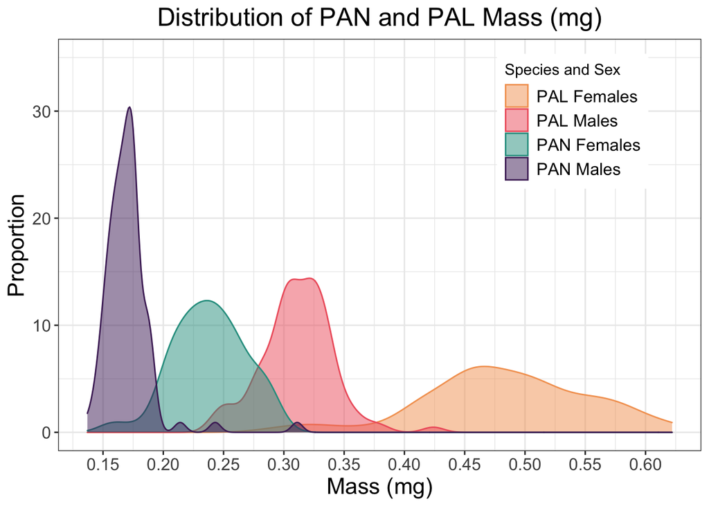

> **TDLR**: Males and females signifcantly differ in dry mass for both species. Female mass variance is > than male.

411 flies were weighted to collect mass data. These flies were from all the trials, including ones not analysed in these results. *A note on cleaning up missing values* - some flies escaped after fight or when weighing they became decapitated so I am removing them. Sometimes only have one opponent. For the sake of looking at distribution of masses I have kept them.

```r
flymass_sum <- flymass_meta %>%
  na_if(0.000) %>% #replace all values which are 0 with NA
  group_by(Species, Sex) %>%
  dplyr::summarise("sample size" = n(),
                   mean = mean(Mass, na.rm = TRUE),
            median = median(Mass, na.rm = TRUE),
            sd = sd(Mass, na.rm = TRUE),
            min = min(Mass, na.rm = TRUE),
            max = max(Mass, na.rm = TRUE),
            IQR = IQR(Mass, na.rm = TRUE)
            )
flymass_sum
```

```
## # A tibble: 4 × 9
## # Groups:   Species [2]
##   Species Sex   `sample size`  mean median     sd   min   max    IQR
##   <chr>   <chr>         <int> <dbl>  <dbl>  <dbl> <dbl> <dbl>  <dbl>
## 1 PAL     F               111 0.484  0.485 0.0683 0.291 0.622 0.0770
## 2 PAL     M               111 0.311  0.312 0.0295 0.241 0.424 0.0320
## 3 PAN     F               111 0.238  0.239 0.0297 0.154 0.296 0.0405
## 4 PAN     M               111 0.171  0.169 0.0210 0.137 0.311 0.0170
```

Thus, I conducted a t-test analysis of the mass of PAN and PAL, first species and then sex.

```r
# t-test of mass and Species
lm_mass_species <- lm(Mass ~ Species, data = flymass_meta)
summary(lm_mass_species)
```

```
##
## Call:
## lm(formula = Mass ~ Species, data = flymass_meta)
##
## Residuals:
##      Min       1Q   Median       3Q      Max
## -0.16083 -0.05783 -0.01188  0.05317  0.22017
##
## Coefficients:
##              Estimate Std. Error t value Pr(>|t|)
## (Intercept)  0.401828   0.005522   72.77   <2e-16 ***
## SpeciesPAN  -0.196945   0.007962  -24.73   <2e-16 ***
## ---
## Signif. codes:  0 '***' 0.001 '**' 0.01 '*' 0.05 '.' 0.1 ' ' 1
##
## Residual standard error: 0.07887 on 391 degrees of freedom
##   (51 observations deleted due to missingness)
## Multiple R-squared:  0.6101, Adjusted R-squared:  0.6091
## F-statistic: 611.8 on 1 and 391 DF,  p-value: < 2.2e-16
```

```r
Anova(lm_mass_species)
```

```
## Anova Table (Type II tests)
##
## Response: Mass
##           Sum Sq  Df F value    Pr(>F)
## Species   3.8053   1   611.8 < 2.2e-16 ***
## Residuals 2.4319 391
## ---
## Signif. codes:  0 '***' 0.001 '**' 0.01 '*' 0.05 '.' 0.1 ' ' 1
```

A linear model was fitted showing interactive effect between sex and species. Residual standard error was 0.0425 with r2 0.887, with F(3,389) = 1022, p <0.001.

```r
# t-test of mass and Species
lm_mass_species <- lm(Mass ~ Species * Sex, data = flymass_meta)
summary(lm_mass_species)
```

```
##
## Call:
## lm(formula = Mass ~ Species * Sex, data = flymass_meta)
##
## Residuals:
##       Min        1Q    Median        3Q       Max
## -0.192907 -0.018720  0.000021  0.018280  0.140280
##
## Coefficients:
##                  Estimate Std. Error t value Pr(>|t|)
## (Intercept)      0.483907   0.004108  117.81   <2e-16 ***
## SpeciesPAN      -0.245927   0.005973  -41.17   <2e-16 ***
## SexM            -0.172618   0.005957  -28.98   <2e-16 ***
## SpeciesPAN:SexM  0.105359   0.008585   12.27   <2e-16 ***
## ---
## Signif. codes:  0 '***' 0.001 '**' 0.01 '*' 0.05 '.' 0.1 ' ' 1
##
## Residual standard error: 0.04249 on 389 degrees of freedom
##   (51 observations deleted due to missingness)
## Multiple R-squared:  0.8874, Adjusted R-squared:  0.8865
## F-statistic:  1022 on 3 and 389 DF,  p-value: < 2.2e-16
```

```r
Anova(lm_mass_species)
```

```
## Anova Table (Type II tests)
##
## Response: Mass
##             Sum Sq  Df F value    Pr(>F)
## Species     3.7266   1 2064.26 < 2.2e-16 ***
## Sex         1.4578   1  807.50 < 2.2e-16 ***
## Species:Sex 0.2719   1  150.62 < 2.2e-16 ***
## Residuals   0.7023 389
## ---
## Signif. codes:  0 '***' 0.001 '**' 0.01 '*' 0.05 '.' 0.1 ' ' 1
```

A quasipoisson GLM (z(290) = 6.532, p < 0.001) was used to test if mass and total acts of aggression were correlated.

```r
glm_total_mass_ag <- glm(total_ag_acts ~ Mass * Species, pan_pal, family = poisson)
dispersiontest(glm_total_mass_ag, trafo =1)
```

```
##
##  Overdispersion test
##
## data:  glm_total_mass_ag
## z = 6.5318, p-value = 3.249e-11
## alternative hypothesis: true alpha is greater than 0
## sample estimates:
##    alpha
## 8.063702
```

```r
summary(glm_total_mass_ag)
```

```
##
## Call:
## glm(formula = total_ag_acts ~ Mass * Species, family = poisson,
##     data = pan_pal)
##
## Deviance Residuals:
##     Min       1Q   Median       3Q      Max
## -4.1254  -2.4408  -1.2524   0.8988   9.6492
##
## Coefficients:
##                 Estimate Std. Error z value Pr(>|z|)
## (Intercept)       2.0746     0.1171  17.709   <2e-16 ***
## Mass              0.1177     0.2859   0.412    0.681
## SpeciesPAN       -0.3289     0.2128  -1.546    0.122
## Mass:SpeciesPAN  -0.1246     0.9043  -0.138    0.890
## ---
## Signif. codes:  0 '***' 0.001 '**' 0.01 '*' 0.05 '.' 0.1 ' ' 1
##
## (Dispersion parameter for poisson family taken to be 1)
##
##     Null deviance: 2351.6  on 291  degrees of freedom
## Residual deviance: 2280.1  on 288  degrees of freedom
##   (22 observations deleted due to missingness)
## AIC: 3172.1
##
## Number of Fisher Scoring iterations: 5
```

```r
Anova(glm_total_mass_ag)
```

```
## Analysis of Deviance Table (Type II tests)
##
## Response: total_ag_acts
##              LR Chisq Df Pr(>Chisq)
## Mass           0.1504  1     0.6982
## Species       25.9861  1  3.439e-07 ***
## Mass:Species   0.0190  1     0.8904
## ---
## Signif. codes:  0 '***' 0.001 '**' 0.01 '*' 0.05 '.' 0.1 ' ' 1
```

# Figures

### Boxplot of total aggressive acts counts by temp, sex, species.

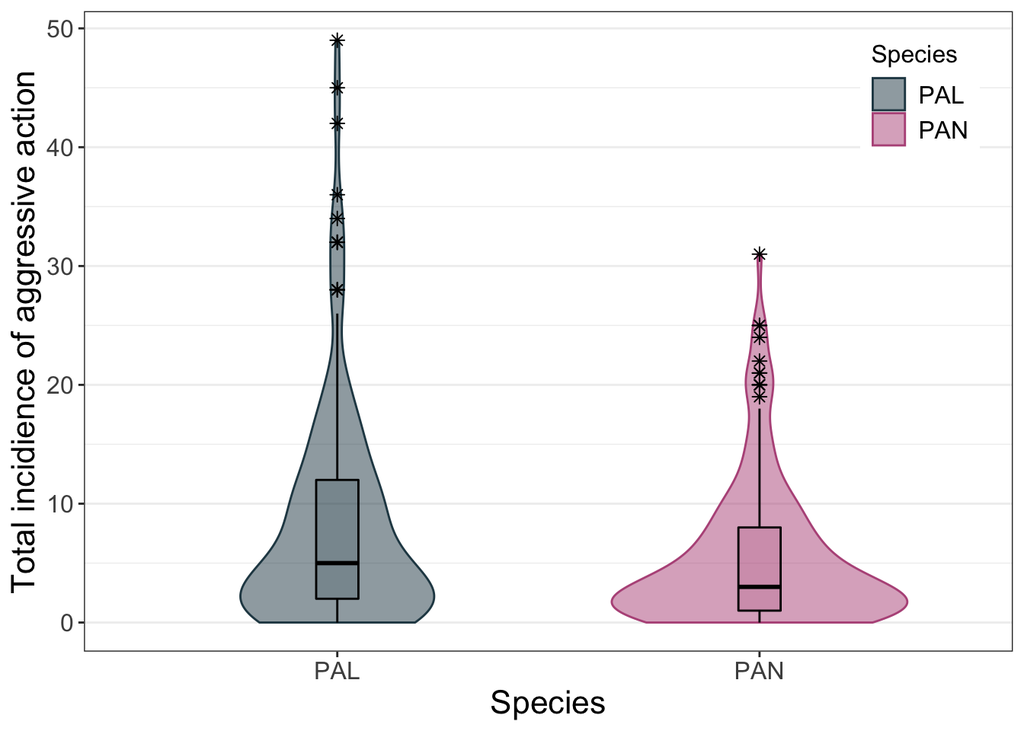

seperated by sex and species

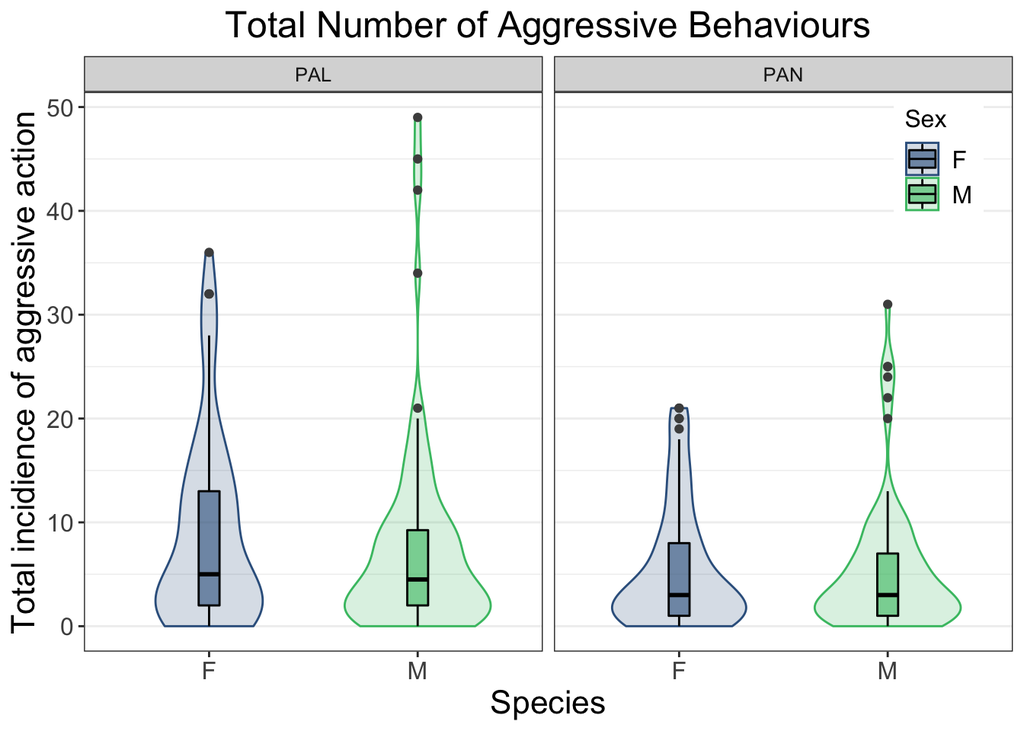

### Counts of aggressive behaviour

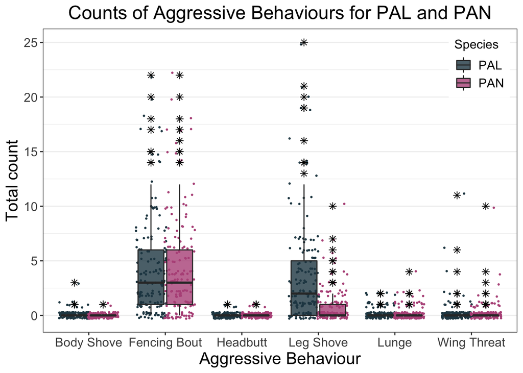

```r
plot_counts_ag_behaviour <- pan_pal %>%
  rename("Body Shove" = DurNBodyShove, # relabel so nice
         "Fencing Bout" = DurNFencing,
         Headbutt = DurNHeadbutt,
         "Leg Shove" = DurNLegShove,
         "Lunge" = DurNLunge,
         "Wing Threat" = DurNWingThreat) %>%
  pivot_longer(c(2, 4:7, 10), names_to = "ag_act", values_to = "Count") %>%
  ggplot(aes(y = Count, x = ag_act, fill = Species)) +
 #     geom_col(position = "dodge", outlier.alpha = 1, outlier.color = "black") +
      geom_point(pch = 21, position = position_jitterdodge(jitter.height = 0.3, seed = 1),
               alpha = 1, size = 0.4, show.legend = FALSE, aes(colour = Species)) +
        geom_boxplot(alpha = 0.8, outlier.colour = "#000000",
                     outlier.alpha = 1, outlier.shape = 8, outlier.size = 2) +
    scale_fill_manual(values = c("#264653", "#B75688")) +
    scale_colour_manual(values = c("#264653", "#B75688")) +
      labs(title = "Counts of Aggressive Behaviours for PAL and PAN",
                  x = "Aggressive Behaviour",
                  y = "Total count") +
    scale_y_continuous(breaks = seq(0,25, by = 5)) +
    theme_masters +
        theme(panel.grid = element_line(color = "gray94"), #grid
              panel.grid.major.x = element_blank(),
          legend.position = c(0.92,0.88))
plot_counts_ag_behaviour
```

Separated for each sex.s

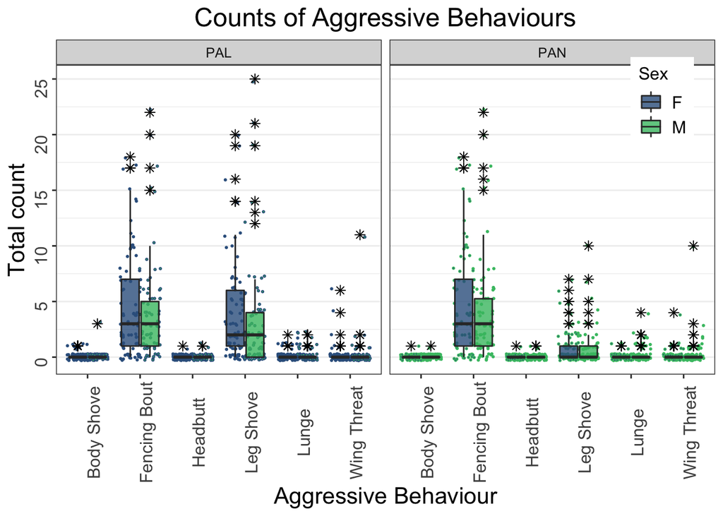

```r
plot_counts_ag_behaviour_sex <- pan_pal %>%
  rename("Body Shove" = DurNBodyShove, # relabel so nice
         "Fencing Bout" = DurNFencing,
         Headbutt = DurNHeadbutt,
         "Leg Shove" = DurNLegShove,
         "Lunge" = DurNLunge,
         "Wing Threat" = DurNWingThreat) %>%
  pivot_longer(c(2, 4:7, 10), names_to = "ag_act", values_to = "Count") %>%
  ggplot(aes(y = Count, x = ag_act, fill = Sex)) +
 #     geom_col(position = "dodge", outlier.alpha = 1, outlier.color = "black") +
      geom_point(pch = 21, position = position_jitterdodge(jitter.height = 0.3, seed = 1),
               alpha = 1, size = 0.4, show.legend = FALSE, aes(colour = Species)) +
        geom_boxplot(alpha = 0.8, outlier.colour = "#000000",
                     outlier.alpha = 1, outlier.shape = 8, outlier.size = 2) +
    scale_color_viridis(discrete = TRUE, option = "D", begin = 0.3, end = 0.7) +
    scale_fill_viridis(discrete = TRUE, option = "D", begin = 0.3, end = 0.7) +
      labs(title = "Counts of Aggressive Behaviours",
                  x = "Aggressive Behaviour",
                  y = "Total count") +
  facet_wrap(~Species) +
    scale_y_continuous(breaks = seq(0,25, by = 5)) +
    theme_bw() +
        theme(panel.grid = element_line(color = "gray94"), #grid
              panel.grid.major.x = element_blank(),
              text = element_text(size = 12),
              plot.title = element_text(hjust = 0.5, size = 18),
          axis.text = element_text(size = 12, angle = 90),
          axis.title = element_text(size = 16),
          legend.text = element_text(size = 12),
          legend.background = element_rect(fill="white"),
          legend.position = c(0.92,0.88))
plot_counts_ag_behaviour_sex
```

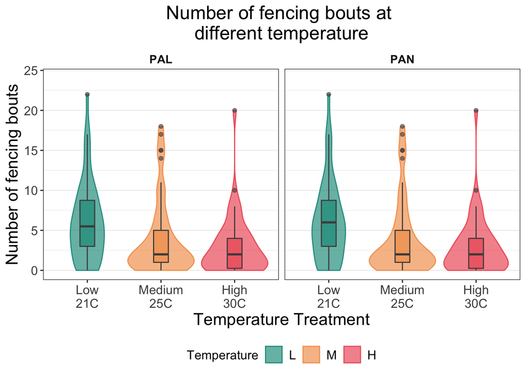

```r
plot_temp_bouts <- ggplot(pan_pal, aes(y = DurNFencing, x = Temp, fill = Temp)) +
  geom_violin(aes(colour = Temp), alpha = 0.7) +
  geom_boxplot(width = 0.2, colour = "gray30", alpha = 0.8,
               show.legend = FALSE, outlier.alpha = 0.6, outlier.color = "gray30") +
  scale_fill_manual(name="Temperature",
                    values = c("#2A9D8F", "#F4A261", "#ef626c")) +
  scale_colour_manual(name="Temperature",
                      values = c("#2A9D8F", "#F4A261", "#ef626c")) +
  facet_wrap(~Species) + # Remove to get overall pattern
  labs(title = "Number of fencing bouts at \ndifferent temperature",
         x = "Temperature Treatment",
         y = "Number of fencing bouts") +
    scale_x_discrete(breaks=c("L", "M", "H"),
                      labels=c("Low\n21C", "Medium\n25C", "High\n30C")) +
  # scale breaks
 ylim(0,24) +
   # scale_y_continuous(breaks = seq(0,30, by = 5)) +
      theme_bw() +
      theme( text = element_text(size = 12),
              plot.title = element_text(hjust = 0.5, size = 18),
          axis.text = element_text(size = 12),
          axis.title = element_text(size = 16),
          legend.text = element_text(size = 12),
              legend.position = "bottom",
            panel.grid = element_line(color = "gray94"), #grid
              panel.grid.major.x = element_blank(),
             strip.background = element_blank(),
          strip.text = element_text(size=11, face="bold"))
plot_temp_bouts
```

### Total number of wins per species

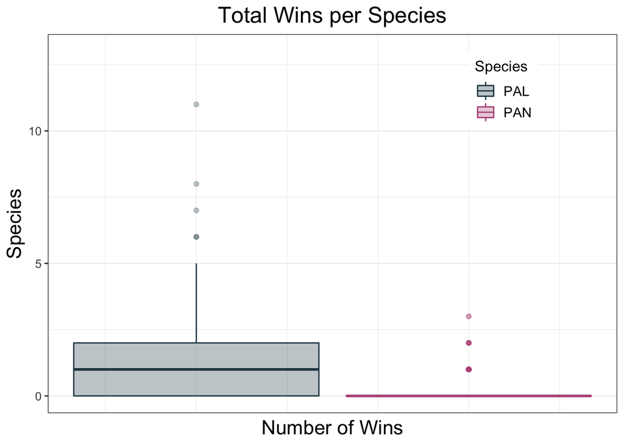

```r
wins_label <-  winners_losers %>%
  group_by(Species) %>%
  summarise(wins = sum(wins))

plot_cursed_wins <- ggplot(winners_losers, aes(y = wins, colour = Species)) +
  geom_boxplot(orientation = "x", aes(fill = Species), alpha = 0.3,
               width = 0.3) +
      scale_fill_manual(values = c("#264653", "#B75688")) +
    scale_colour_manual(values = c("#264653", "#B75688")) +
    labs(title = "Total Wins per Species") +
  xlab("Number of Wins") + ylab("Species") +
  ylim(0,13) +
  theme_bw() +
      theme(axis.text.x = element_blank(),
            panel.grid = element_line(color = "gray94"), #grid
              panel.grid.major.x = element_blank(),
        axis.ticks.x = element_blank(),
          plot.title = element_text(hjust = 0.5, size = 18),
          axis.title = element_text(size = 16),
        text = element_text(size = 12),
          legend.text = element_text(size = 11),
          legend.background = element_rect(fill="white"),
          legend.position = c(0.8,0.85))
plot_cursed_wins
```

### Proportion of win, loss, draws.

This one is actually wrong in the thesis but not quite sure how.

```r
prop_perc <- winners_losers %>%
  group_by(Species, Sex) %>%
  filter(Species == "PAL") %>%
      dplyr::summarise(win = sum(wins)/sum(bouts),
                       loss = sum(loses)/sum(bouts),
                       draw = sum(draws)/sum(bouts)) %>%
      pivot_longer(c(win,loss,draw), names_to = "outcome", values_to = "percent")
```

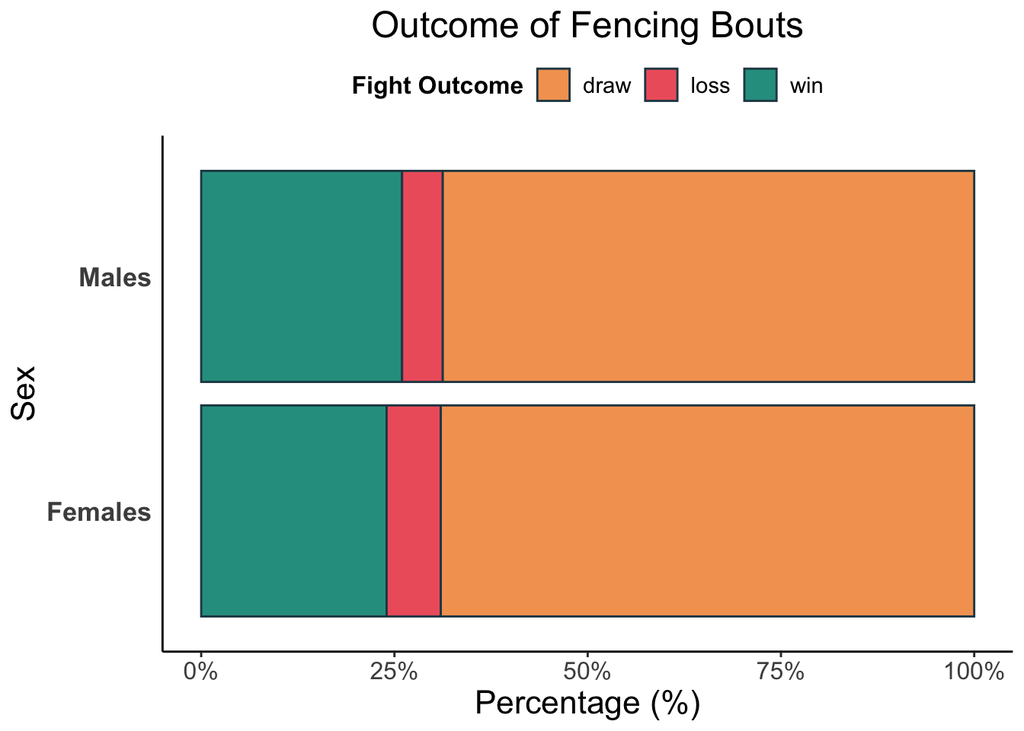

```r
# THE GRAPH
  ggplot(prop_perc, aes(y = Sex, x = percent, fill = outcome)) +
  geom_col(position = "fill", colour = "#264653") +
    scale_fill_manual(name="Fight Outcome",
                    values = c("#F4A261", "#ef626c", "#2A9D8F"))+
    labs(title = "Outcome of Fencing Bouts",
         x = "Percentage (%)",
           y = "Sex") +
    scale_x_continuous(labels = scales::percent) +
    scale_y_discrete(breaks=c("F", "M"),
                      labels=c("Females", "Males")) +
      theme_classic() +
      theme(panel.grid = element_blank(), #grid
        axis.ticks.y = element_blank(),
        axis.text.y = element_text(size = 13, face = "bold"),
                axis.text.x = element_text(size = 12),
          plot.title = element_text(hjust = 0.5, size = 18),
          axis.title = element_text(size = 16, margin = margin(2,2,2,2, unit = "cm")),
          text = element_text(size = 12),
          legend.title = element_text(size = 12, face = "bold"),
          legend.text = element_text(size = 11),
          legend.background = element_rect(fill="white"),
          legend.position = "top"
          )
```

Table for labels - from PAL persepective

| Sex | Outcome | Proportion |
| --- | --- | --- |
| F | win | 0.2398922 |
| F | loss | 0.0700809 |
| F | draw | 0.6900270 |
| M | win | 0.2598684 |
| M | loss | 0.0526316 |
| M | draw | 0.6875000 |

### Species Mass

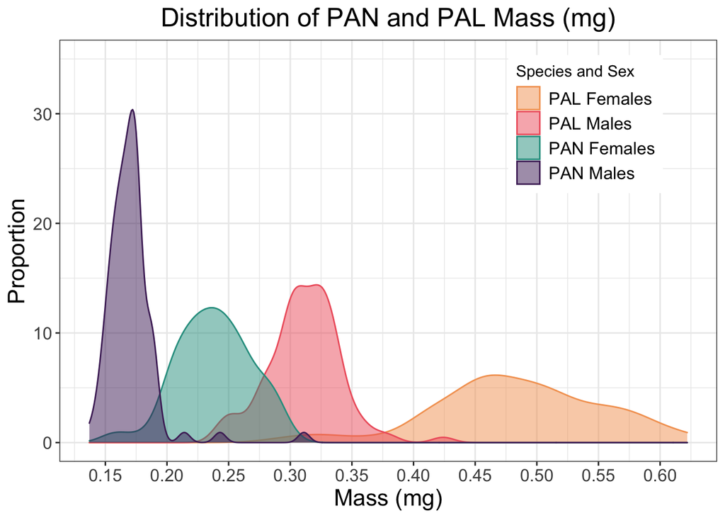

```r
plot_massdistribution <- flymass_meta %>%
  unite(SpeciesSex, Species, Sex, sep = "_", remove = FALSE, na.rm = TRUE) %>%
              # not the most elegant way of doing this
  ggplot(aes(x = Mass, fill = SpeciesSex, colour = SpeciesSex, na.rm = TRUE)) +
    geom_density(alpha = 0.5) +
    scale_fill_manual(name="Species and Sex",
                      labels = c("PAL Females", "PAL Males", "PAN Females", "PAN Males"),
                    values = c("#F4A261", "#ef626c", "#2A9D8F", "#4E2966")) + #264653")) +
  scale_colour_manual(name="Species and Sex",
                      labels = c("PAL Females", "PAL Males", "PAN Females", "PAN Males"),
                      values = c("#F4A261", "#ef626c", "#2A9D8F", "#4E2966")) + #264653")) +
    labs(title = "Distribution of PAN and PAL Mass (mg)",
         x ="Mass (mg)",
         y = "Proportion") +
  ylim(0,35) +
      scale_x_continuous(breaks = seq(0,0.7, by = 0.05)) +
  theme_bw() +
  theme(legend.position = c(0.8,0.8),
        plot.title = element_text(hjust = 0.5, size = 18),
          axis.text = element_text(size = 12),
          axis.title = element_text(size = 16),
          legend.text = element_text(size = 12),
        legend.background = element_rect(fill="white")
  )
plot_massdistribution
```